# Activity 3: Overview of the original paper

Author

Karthik Thrikkadeeri

Published

March 6, 2025

**Submit this activity by pushing it to a new “Semester Project” git repository before class on 6 March 2025.**

**Instructions for completion**:

- Download the `.qmd` source code for this file from the [course git repository](https://gitlab.com/gklab/teaching/reproducible-research-s25/-/raw/main/activities/activity-3.qmd?ref_type=heads).
- Edit the document with your responses to the questions, and render the document into an `html` file.
- Commit and push both the `qmd` source and the rendered `html` file to your semester project git repository.

The goals for this activity are for you to:

- finalize the published paper in your field whose results you aim to reproduce as part of the semester project for this course,
- thoroughly explore the dataset and understand the “data generation process”
- identify the software packages you will need to implement to complete this reproduction analysis.

Fill out the information in the sections below.

# Citation

> Add an in-text citation to your publication here:

Montaño-Centellas, McCain, and Loiselle (2020)

# Main results

> What are the core results from the original analysis that you wish to reproduce?

The core results are:

- Patterns of bird functional and phylogenetic diversity along elevational gradients of the world (quadratic regression model, Figure 2)
- Trends in bird functional and phylogenetic diversity along elevational gradients of the world, after controlling for species richness (quadratic polynomial regression models for individual mountains and for all mountains together, Figure 3, Table 1)
- Deterministic processes driving global patterns (Figure 4, Table 2)
  - Effect of latitude on patterns of elevational change (Figure 4)

# Details of the dataset

> Provide an overview of all details regarding the original dataset that you feel will be relevant for your re-analysis. For example, what are the different “types” of data relavent to this analysis (e.g. what are the columns in the dataset? Is each column categorical or continuous? How many observations are present? How are missing values represented?)
- The processed dataset that the authors have made available on Dryad is what I need to base the analyses and visualisations off.
- The data exist as a single `.xlsx` file, which I have renamed as `montano_dryad_data.xlsx` in my `data/` directory.
- The `.xlsx` file has two sheets; the actual data are in the second sheet named `FDPD_Supporting` while the first sheet `Details` serves as a README for metadata.
- The data comprise 15 columns, of which the first is categorical (mountain name) and the rest are all numerical (including richness and diversity metrics, and standardised effect sizes with their p-values).
  - The column `elevation` is numerical, but it is worth noting that it is at the resolution of 100 m elevational bands. (So, depending on the question, this column may be treated as categorical.)
- There are 954 observations in the dataset, across 46 mountains of the world.
- Likely because this is the processed dataset ready to be analysed, there are no missing values.
- Similarly, I will need to assume that there were no errors in the several steps leading up to this processed dataset.

```
# A tibble: 6 × 15
  Mountain  elevation Richness  FRic SES.FRic p.SESFRic  FDis SES.FDis p.SESFDis
  <chr>         <dbl>    <dbl> <dbl>    <dbl>     <dbl> <dbl>    <dbl>     <dbl>
1 Aguarague       400      228  41.4    0.253     0.148  1.44   -0.903     0.156
2 Aguarague       500      219  41.7    0.380     0.24   1.44   -0.929     0.186
3 Aguarague       600      212  41.7    0.410     0.3    1.43   -1.20      0.146
4 Aguarague       700      238  42.8    0.367     0.966  1.45   -0.577     0.196
5 Aguarague       800      225  42.6    0.445     0.698  1.46   -0.356     0.276
6 Aguarague       900      219  42.6    0.485     0.742  1.45   -0.373     0.3
# ℹ 6 more variables: PD <dbl>, SES.PD <dbl>, p.SESPD <dbl>, MPD <dbl>,
#   SES.MPD <dbl>, p.SESMPD <dbl>
```

# Details of the analytical approach

> Provide an overview of the analytical approach used in the original study. Include both conceptual and practical information (e.g. what *kind* of analyses were conducted, and using which software packages?)
- After calculating the four diversity metrics for each elevational band across all mountains, the authors first explored elevational patterns in these metrics using quadratic regressions. Based on the coefficients and overall shape of the polynomial curves, they classified patterns in each mountain as one of nine categories, including one for non-significant patterns. (See [Appendix S2](https://onlinelibrary.wiley.com/action/downloadSupplement?doi=10.1111%2Fgeb.13021&file=geb13021-sup-0001-Supinfo.pdf).)
- For exploring deterministic processes driving community assembly across mountains, they used a null model approach to test whether the diversity patterns they observed were different from those from random assembly. The null models were created by randomising tip labels of trait and phylogeny data (in 1000 runs) while fixing the rows and columns of the observed community data matrix. The deviation of each observed metric from the average of the null model was standardised to obtain standardised effect sizes (SES). The direction of SES suggested clustering/overdispersion while its magnitude hinted at the strength of the signal of the deterministic process.
- They further tested global trends in elevational patterns of deterministic signal by modelling the SES of each diversity metric against normalised elevation in linear mixed-effects models.
- Finally, they tested for the effect of latitude on patterns of deterministic signal using a two-stage mixed-effects model. This is a type of hierarchical multivariate meta-regression, where a linear model is first fitted and then its slope and associated variance are used as response variables in a multivariate meta-regression. The `metafor` package was used for this analysis.

# Path to reproduction

> - Describe what data are available, including links to all repositories.
> - Describe what code is available, including links to all repositories.
- There is no code available for any step of this study.
- As described above, the processed dataset ready for analyses has been made available [on Dryad](https://doi.org/10.5061/dryad.tqjq2bvtc). This contains functional and phylogenetic richness and diversity metrics calculated at the level of 100 m elevation bands across 46 mountains of the world, along with their SES and corresponding p-values.
- I can perform the quadratic regression with the diversity metrics to obtain classifications of elevational patterns. I do not need a separate package for this step, as I can use the `lm()` function from the base `stats` package.
- Since the authors have not provided the original trait and phylogeny data, or the community data matrix, I will not be able to reproduce the SES calculation. But I can reproduce the linear mixed-effects models using the `lmer()` function from the `lme4` package.
- Since there is no latitude data (or any other geographical data like country) for the mountains, I will not be able to reproduce their final meta-regression model testing for a latitudinal effect.

# Getting familiar with the data

> Download the dataset and use `dplyr` to start familiarizing yourself with the structures and patterns in the dataset. Please include your code and the output below. (Try making at least 5 plots to conduct [exploratory data analysis](https://r4ds.hadley.nz/EDA.html), and run 1–2 simple statistical models).

First, let’s explore how the 46 mountains are distributed elevationally.

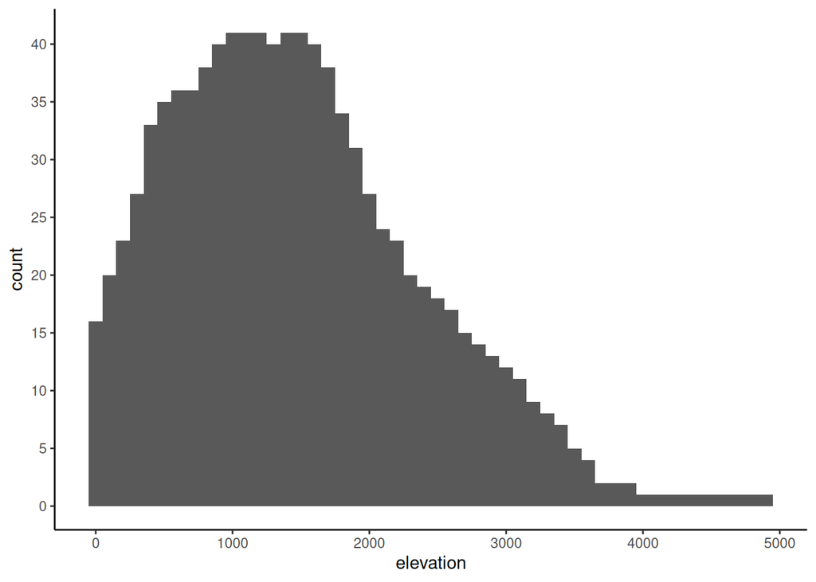

```r
data_dryad %>%
  ggplot() +
  geom_histogram(aes(x = elevation), binwidth = 100) +
  scale_y_continuous(breaks = seq(0, 50, 5))
```

Clearly, there is only one mountain that exceeds 4000 m asl, which is Annapurna.

Let’s now arrange the mountains in descending order of their maximum elevation.

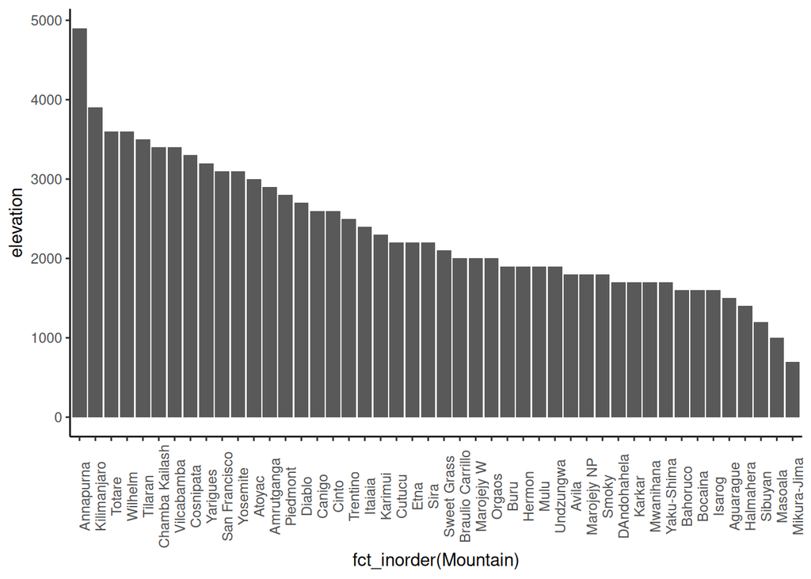

```r
library(forcats)

data_dryad %>%
  group_by(Mountain) %>%
  reframe(elevation = max(elevation)) %>%
  arrange(desc(elevation)) %>%
  ggplot(aes(x = fct_inorder(Mountain), y = elevation)) +
  geom_col() +
  theme(axis.text.x = element_text(angle = 90))
```

Next, let’s check how species richness changes across elevation.

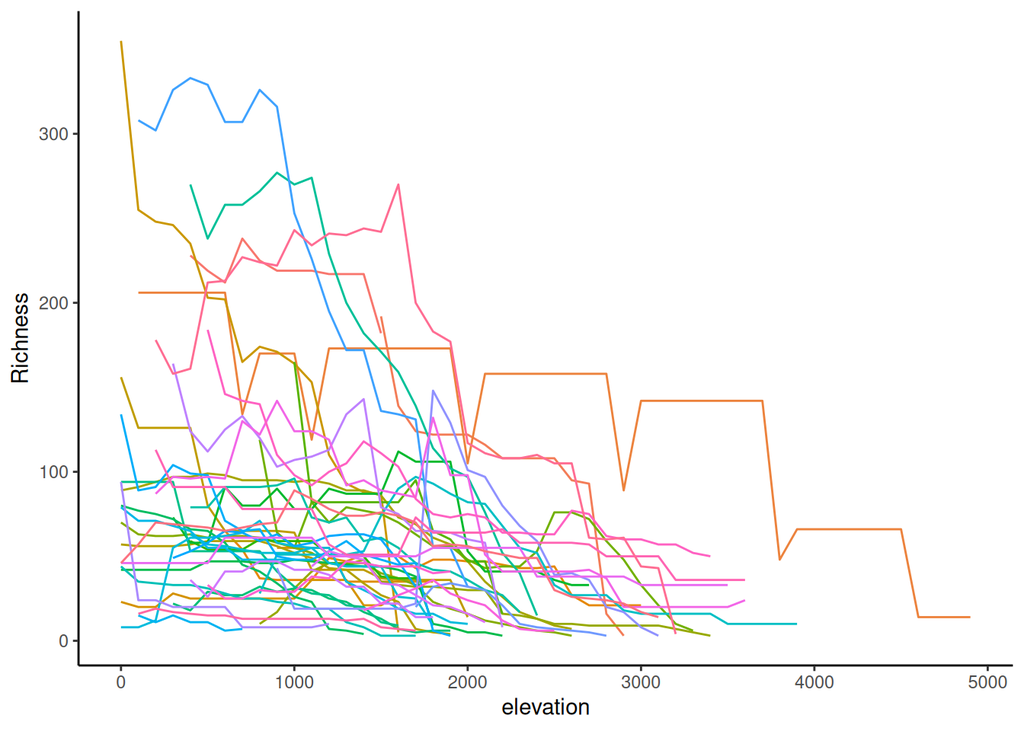

```r
data_dryad %>%
  ggplot(aes(x = elevation, y = Richness, colour = Mountain)) +
  geom_line() +
  theme(legend.position = "none")
```

This shows that some mountains have interesting patterns, where richness stays exactly the same across multiple elevation bands. My first guess is that this has something to do with how species observations were aggregated across bands, but this is certainly worth keeping in mind in further analyses.

Let’s now take a look at the diversity metrics.

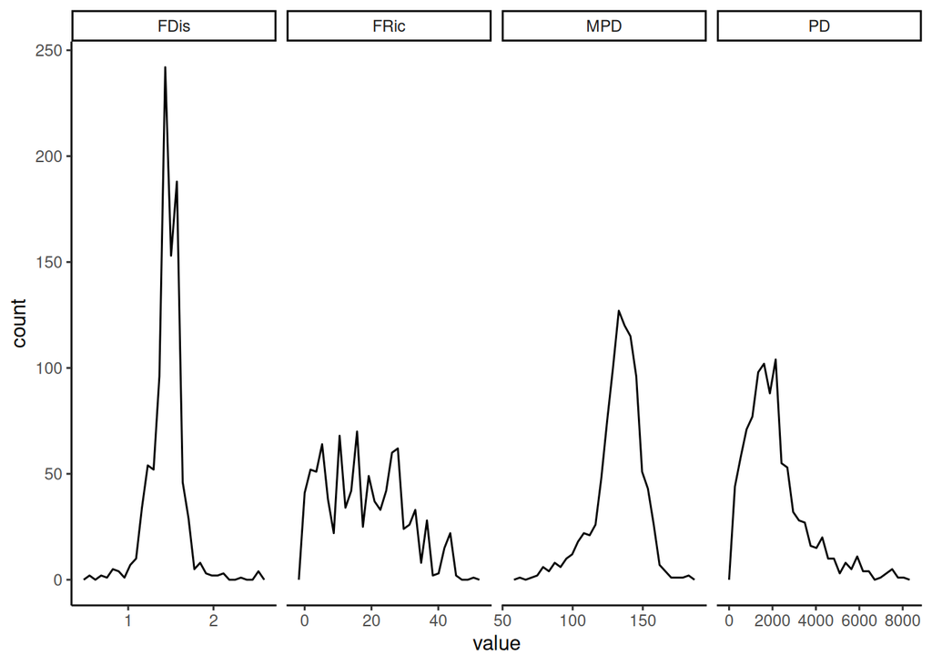

```r
library(tidyr)

# diversity metrics
data_diversity <- data_dryad %>%
  pivot_longer(cols = c("FRic", "FDis", "PD", "MPD"),
               names_to = "metric", values_to = "value") %>%
  select(Mountain, elevation, metric, value)

data_diversity %>%
  ggplot(aes(x = value)) +
  geom_freqpoly() +
  facet_wrap(~ metric, scales = "free_x", nrow = 1)
```

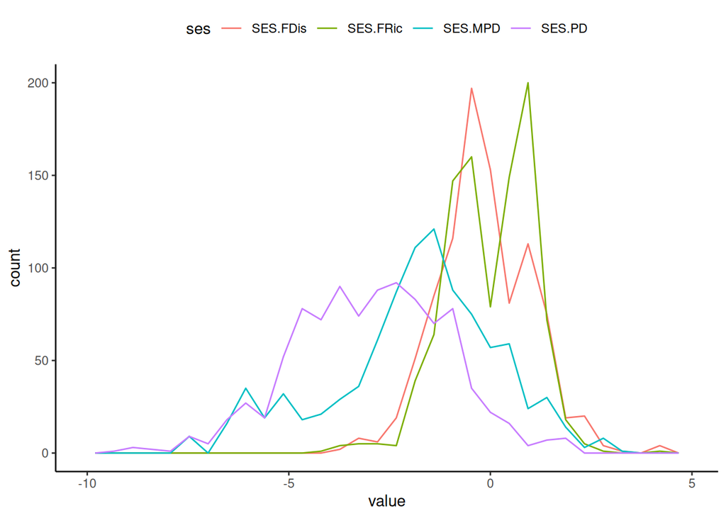

```r
# SES for four metrics
data_ses <- data_dryad %>%
  pivot_longer(cols = starts_with("SES"),
               names_to = "ses", values_to = "value") %>%
  select(Mountain, elevation, ses, value)

data_ses %>%
  ggplot(aes(x = value, colour = ses)) +
  geom_freqpoly() +
  theme(legend.position = "top")
```

The first plot shows just how different the scales are for the four diversity metrics, whereas the second plot shows that their SESs are actually comparable.

Let’s test if the functional richness and diversity metrics are correlated, using their SES values.

```r
summary(lm(SES.FDis ~ SES.FRic, data = data_dryad))
```

```
Call:
lm(formula = SES.FDis ~ SES.FRic, data = data_dryad)

Residuals:
    Min      1Q  Median      3Q     Max
-2.6018 -0.4177 -0.0192  0.4196  3.5840

Coefficients:
            Estimate Std. Error t value Pr(>|t|)
(Intercept) -0.14366    0.02397  -5.992 2.93e-09 ***
SES.FRic     0.82634    0.02283  36.191  < 2e-16 ***
---
Signif. codes:  0 '***' 0.001 '**' 0.01 '*' 0.05 '.' 0.1 ' ' 1

Residual standard error: 0.7404 on 952 degrees of freedom
Multiple R-squared:  0.5791,    Adjusted R-squared:  0.5787
F-statistic:  1310 on 1 and 952 DF,  p-value: < 2.2e-16
```

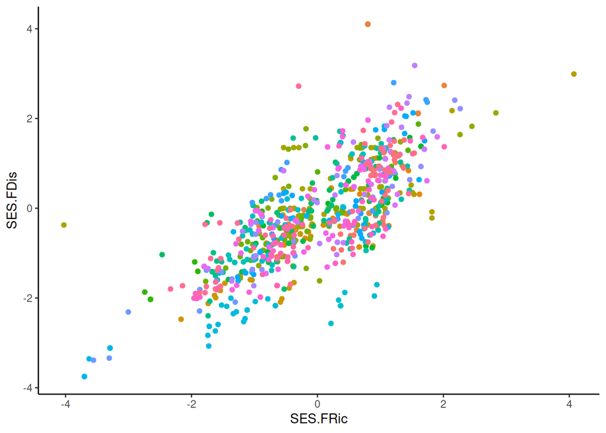

```r
data_dryad %>%
  ggplot(aes(x = SES.FRic, y = SES.FDis, colour = Mountain)) +
  geom_point() +
  theme(legend.position = "none")
```

There seems to be a correlation, which is significant according to the linear model summary, although the model itself needs to be refined by accounting for random variation across mountains. Let’s check if a similar pattern exists for phylogenetic metrics.

```r
summary(lm(SES.MPD ~ SES.PD, data = data_dryad))
```

```
Call:
lm(formula = SES.MPD ~ SES.PD, data = data_dryad)

Residuals:
    Min      1Q  Median      3Q     Max
-3.8431 -1.1546  0.1514  1.0592  5.2834

Coefficients:
            Estimate Std. Error t value Pr(>|t|)
(Intercept)  0.13393    0.10028   1.336    0.182
SES.PD       0.66757    0.02855  23.387   <2e-16 ***
---
Signif. codes:  0 '***' 0.001 '**' 0.01 '*' 0.05 '.' 0.1 ' ' 1

Residual standard error: 1.654 on 952 degrees of freedom
Multiple R-squared:  0.3649,    Adjusted R-squared:  0.3642
F-statistic: 546.9 on 1 and 952 DF,  p-value: < 2.2e-16
```

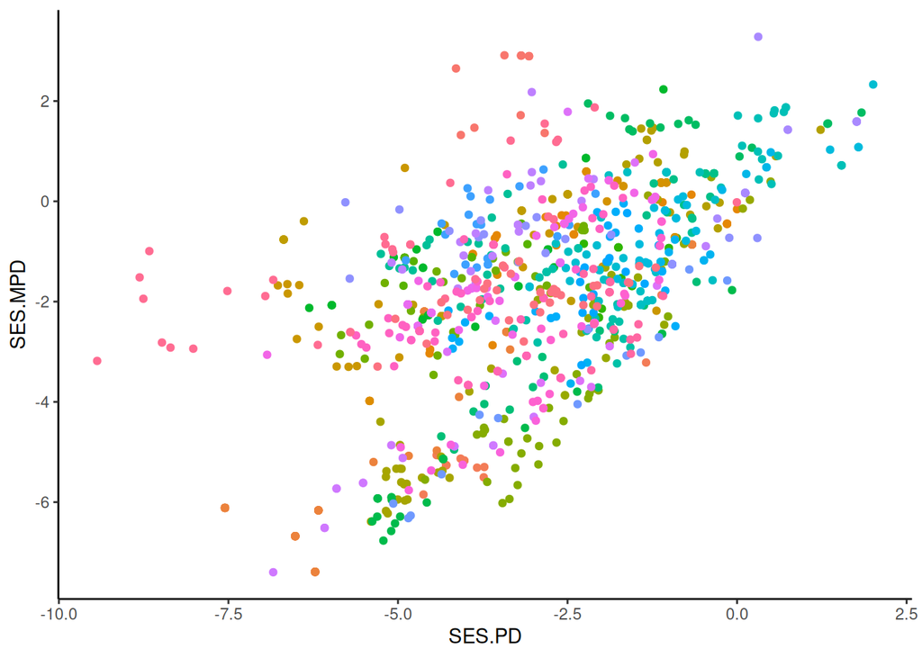

```r
data_dryad %>%
  ggplot(aes(x = SES.PD, y = SES.MPD, colour = Mountain)) +
  geom_point() +
  theme(legend.position = "none")
```

This time the pattern is more complicated, albeit still a significant trend according to the simple linear model.

## References

Montaño-Centellas, Flavia A., Christy McCain, and Bette A. Loiselle. 2020. “Using Functional and Phylogenetic Diversity to Infer Avian Community Assembly Along Elevational Gradients.” *Global Ecology and Biogeography* 29 (2): 232–45. https://doi.org/10.1111/geb.13021.